# TP Times series - Mardoché Clabessi

#### Calcul et Interprétation de la Fonction d’Autocovariance et de l’ACF

Nous calculons ensuite la fonction d’autocovariance empirique et comparons son comportement avec les valeurs théoriques attendues pour un processus AR(2).

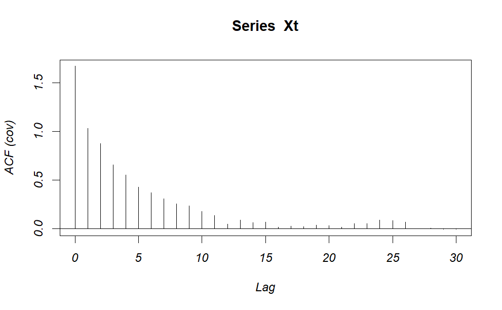

```r
# Fonction d'autocovariance empirique
gamma_hat <- acf(Xt, type = "covariance", plot = T)$acf
```

```r
# Affichage de l'autocovariance et de l'autocorrélation empiriques
cat("Fonction d'autocovariance empirique (jusqu'au lag 10) :", gamma_hat[1:10], "\n")
```

```
Fonction d'autocovariance empirique (jusqu'au lag 10) : 1.671684 1.029579 0.8761929 0.6581831 0.5512082 0.4277748 0.3713854 0.3074719 0.2567139 0.2350211
```

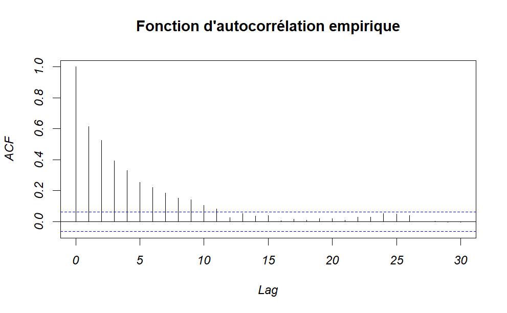

```r
acf(Xt, main = "Fonction d'autocorrélation empirique")
```

En comparant avec les résultats théoriques, nous vérifions si l’autocorrélation suit bien le comportement attendu pour un processus AR(2) causal.

# $\textbf{2.4 Processus ARMA(p,q)}$

#### 9) Avec $\phi = -0.5$ et $\theta = 0.25$

Pour ce processus ARMA(1,1), nous allons vérifier sa causalité et son inversibilité, simuler la série temporelle, puis analyser ses propriétés.

##### Vérification de la causalité et de l’inversibilité

- **Causalité** : Le processus ARMA(1,1) est causal si la valeur absolue de $\phi$ est inférieure à 1, ce qui est le cas ici ($|\phi| = 0.5 < 1$). Ainsi, ce processus est causal.
- **Inversibilité** : Le processus ARMA(1,1) est inversible si la valeur absolue de $\theta$ est inférieure à 1, ce qui est également le cas ici ($|\theta| = 0.25 < 1$). Donc, ce processus est aussi inversible.

##### Simulation du Processus ARMA(1,1)

Nous simulons le processus ARMA(1,1) pour $t = 1, \ldots, n$ avec $n = 1000$, et traçons les fonctions d’autocorrélation (ACF) et d’autocorrélation partielle (PACF).

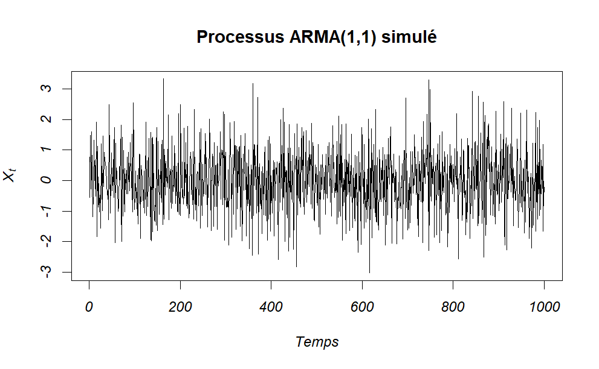

```r
set.seed(123)  # Pour la reproductibilité

# Paramètres du processus ARMA(1,1)
phi <- -0.5
theta <- 0.25
n <- 1000

# Génération du bruit blanc
epsilon <- rnorm(n)

# Initialisation de la série
Xt <- numeric(n)

# Boucle pour générer le processus ARMA(1,1)
Xt[1] <- epsilon[1]
for (t in 2:n) {
  Xt[t] <- phi * Xt[t - 1] + epsilon[t] + theta * ifelse(t > 2, epsilon[t - 1], 0)
}

# Tracé de la série simulée
plot(Xt, type = "l", main = "Processus ARMA(1,1) simulé", xlab = "Temps", ylab = expression(X[t]))
```

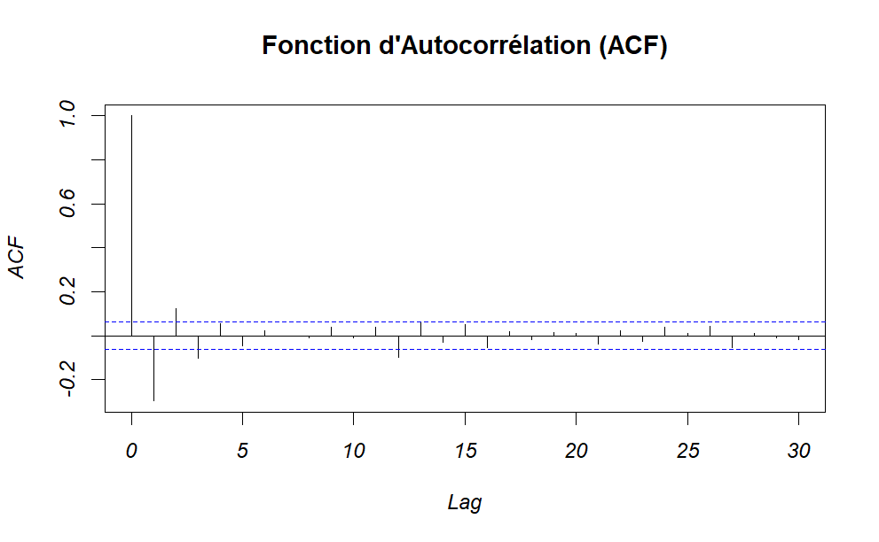

```r
# Tracé des fonctions d’autocorrélation et d’autocorrélation partielle
acf(Xt, main = "Fonction d'Autocorrélation (ACF)")
```

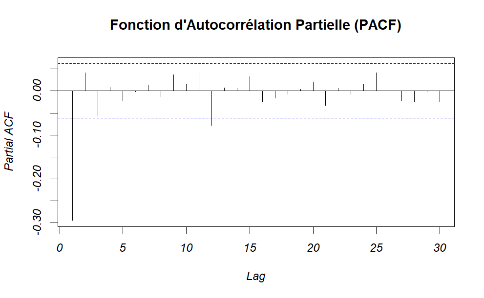

```r
pacf(Xt, main = "Fonction d'Autocorrélation Partielle (PACF)")
```

##### Calcul et Interprétation de la Fonction d’Autocovariance et de l’ACF

Pour évaluer l’autocovariance empirique et confirmer son comportement, nous calculons également l’autocovariance jusqu’à un certain lag.

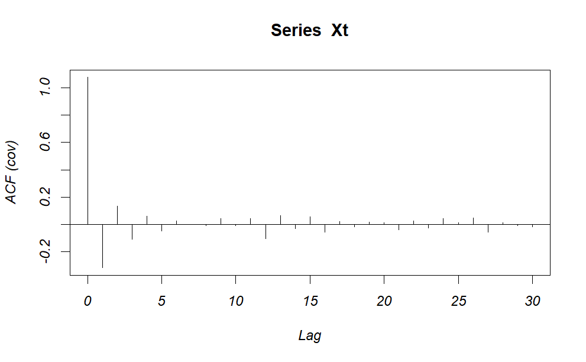

```r
# Fonction d'autocovariance empirique
gamma_hat <- acf(Xt, type = "covariance", plot = T)$acf
```

```r
# Affichage de l'autocovariance empirique (jusqu'au lag 10)
cat("Fonction d'autocovariance empirique (jusqu'au lag 10) :", gamma_hat[1:10], "\n")
```

```
Fonction d'autocovariance empirique (jusqu'au lag 10) : 1.077435 -0.3164399 0.1336608 -0.1072485 0.0593107 -0.04981162 0.02684245 -0.001132318 -0.01033518 0.04157861
```

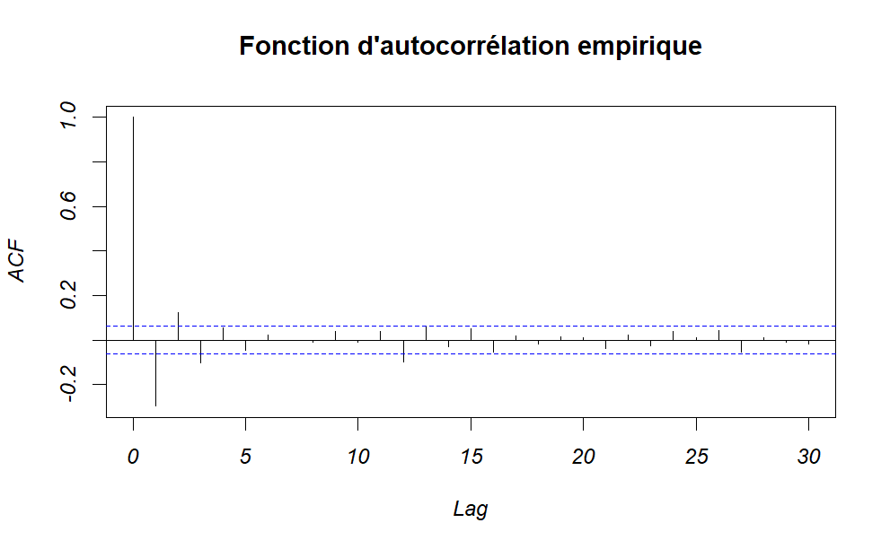

```r
acf(Xt, main = "Fonction d'autocorrélation empirique")
```

L’observation de la fonction d’autocorrélation pour cette simulation correspond au comportement théorique d’un processus ARMA(1,1) causal et inversible, avec un déclin modéré influencé par les valeurs de $\phi$ et $\theta$.

#### Processus ARMA(2,1)

Nous allons maintenant simuler un processus ARMA(2,1) :
$$X_t = \phi_1 X_{t-1} + \phi_2 X_{t-2} +
\varepsilon_t + \theta \varepsilon_{t-1}, \; t \in \mathbb{N}$$

#### 10) On choisit $\phi_1 = -0.5$, $\phi_2 = 0.4$ et $\theta = 0.25$.

##### Vérification de la causalité et de l’inversibilité

- **Causalité** : Un processus ARMA est causal si les racines du polynôme caractéristique associé au processus AR(p) sont toutes à l’extérieur du cercle unité dans le plan complexe. Pour le processus ARMA(2,1) donné, le polynôme est :
  $$1 - \phi_1 z - \phi_2 z^2 = 0$$

##### Cherchons numériquement les racines avec R

```r
# Paramètres du processus AR(2)
phi1 <- -0.5
phi2 <- 0.4

# Calcul des racines de l'équation caractéristique
roots <- polyroot(c(1, -phi1, -phi2))

# Affichage des racines et de leurs modules
cat("Racines :", roots, "\n")
```

```
Racines : -1.075184+0i 2.325184+0i
```

```r
cat("Modules des racines :", Mod(roots), "\n")
```

```
Modules des racines : 1.075184 2.325184
```

Les modules des racines sont tous supérieurs à 1, alors le processus est causal.

- **Inversibilité** : Un processus ARMA est inversible si les racines du polynôme caractéristique associé au processus MA(q) sont toutes à l’extérieur du cercle unité. Pour le processus MA(1) donné, le polynôme est :
  $$1 + \theta z = 0$$

```r
# Paramètres du processus
theta <- 0.25

# Calcul des racines de l'équation caractéristique
roots <- polyroot(c(1, theta))

# Affichage des racines et de leurs modules
cat("Racines :", roots, "\n")
```

```
Racines : -4+0i
```

```r
cat("Modules des racines :", Mod(roots), "\n")
```

```
Modules des racines : 4
```

Le module de la racine est supérieur à 1, alors le processus est inversible.

##### Simulons le processus $X_t$ pour $t = 1, \ldots, n$, avec $n = 1000$.

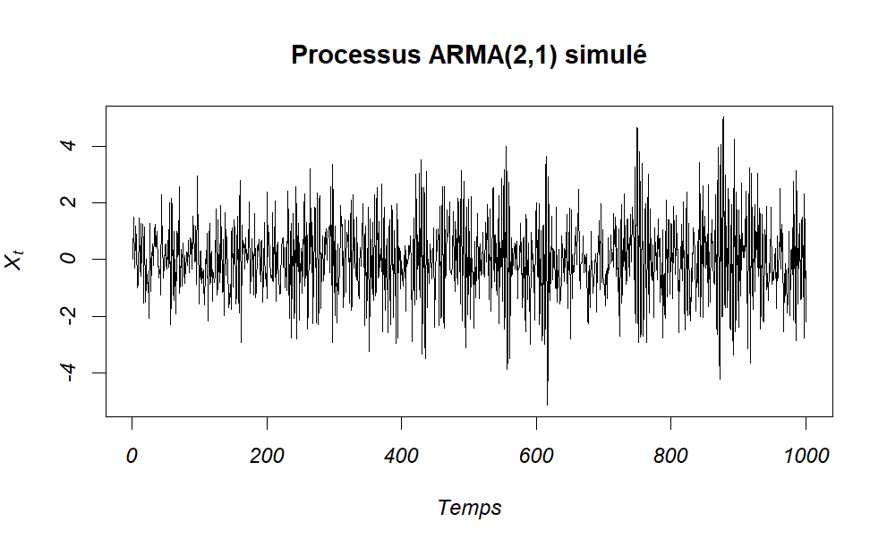

```r
# Paramètres du processus
phi1 <- -0.5
phi2 <- 0.4
theta <- 0.25
n <- 1000  # Nombre d'observations

# Génération du bruit blanc
set.seed(123)  # Pour la reproductibilité
epsilon <- rnorm(n)

# Initialisation de la série
Xt <- numeric(n)

# Boucle pour générer le processus ARMA(2,1)
for (t in 3:n) {
  Xt[t] <- phi1 * Xt[t - 1] + phi2 * Xt[t - 2] + epsilon[t] + theta * epsilon[t - 1]
}
# Tracé de la série simulée
plot(Xt, type = "l", main = "Processus ARMA(2,1) simulé", xlab = "Temps", ylab = expression(X[t]))
```

##### Traçons les fonctions d’autocorrélation et d’autocorrélation partielle.

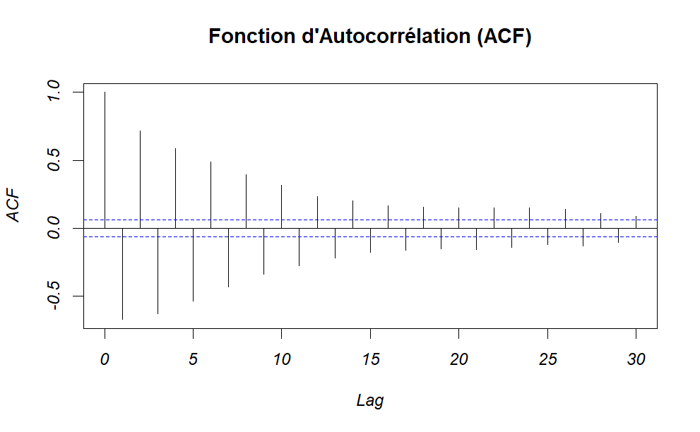

```r
# Tracé des fonctions d’autocorrélation et d’autocorrélation partielle
acf(Xt, main = "Fonction d'Autocorrélation (ACF)")
```

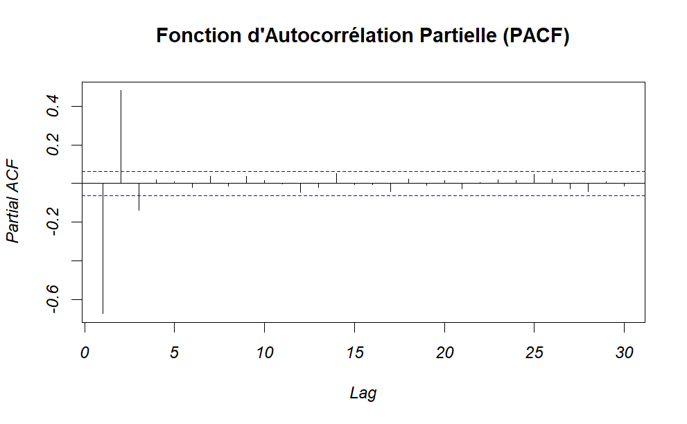

```r
pacf(Xt, main = "Fonction d'Autocorrélation Partielle (PACF)")
```

### Comportements Observés

##### Calculer la fonction d’autocovariance et la fonction d’autocorrélation.

**1. Calcul de la fonction d’autocovariance** $\phi_k$

Pour obtenir les valeurs des premiers $\gamma_k$ (en supposant $k = 0, 1, 2$), on doit résoudre les équations suivantes :

- $$\gamma_0 = \dfrac{\sigma_{\varepsilon}^2 (1 + \theta^2)}{1 - \phi_1^2 -
  \phi_2^2 - 2 \phi_1 \phi_2}$$
- $$\gamma_1 = \dfrac{\phi_1 \gamma_0 + \theta_1 \sigma_{\varepsilon}^2}{1 -
  \phi_2}$$
- $$\gamma_2 = \phi_1 \gamma_1 + \phi_2
  \gamma_0$$

Par récurrence, on a : $\gamma_k = \phi_1 \gamma_{k-1} + \phi_2 \gamma_{k-2}$ pour tout $k >3$.

##### Comportement de l’ACF théorique

Dans notre modèle autorégressif d’ordre 2, l’ACF exhibera différents comportements en fonction des valeurs des paramètres $\phi_1$ et $\phi_2$ :

- **Oscillatoire** si les racines associées à l’équation caractéristique du modèle sont complexes.
- **Exponentiellement décroissant** si les racines sont réelles et les valeurs propres de $\phi_1$ et $\phi_2$ sont inférieures à 1 en module.